# Analyses - Random Forests v3

Joey Hulbert

2/6/2022

## Version 3 Notes

- Comments about this Analysis version
  - It does not subset the data into test or train
    - although I am reconsidering this
  - It only models ’filtered symptoms (5 groups)
    - is it better to ignore the other symptoms or group them all as ‘unhealthy’
    - also worth considering whether dead tops should be grouped.

### Purpose

The purpose of this analysis document is to ensure the reproducability of the results by guiding the reader through the random forest analysis of the factors associated with the health of western redcedar.

### Approach

Root data were shared by citizen scientists in the [Wester Redcedar Dieback Map](https://www.inaturalist.org/projects/western-redcedar-dieback-map) project on iNaturalist.

- These data were then combined with
- Climate data derived using the ClimateNA tool. Instructions for how this tool was used are included in the climate subfolder.
- Topographic data extraced from DEM rasters. Preliminary methods for extracting topo data from GPS points are available in the topo subfolder.
- Soils data downloaded from gSSURRGO databases for Washington and Oregon. Instructions for extracting the soils data using Arc GIS Pro are included in the soils subfolder.

All of the data used in the below analyses are described in the Data Wrangle folder.

### Limitations

- Below are some limitations to these results to clarify
  - representation of the data were heavily biased to the western side of Washington and Oregon (west of the Cascades).

### Next steps

- Do following before next commit
  - calculate better topographic variables (aspect, and those that combine both topo and climate data?)
  - look into what is happening with -9999 values in components
  - does it make sense to group dead tops?
  - try hyperparameter tuning to determine best parameters for model (see https://www.youtube.com/watch?v=Ptd2NXdtHl4 and https://jsimkins2.github.io/geog473-673/random-forest-modeling.html)
  - remove climate data for individual months?
  - check whether valu1 data are available in gssurgo data in addition to muaggat and component

### Notes from meeting with MC

- Next steps
  - Correlation model between all variables - variables will be highly correlated
    - how does the model perform differently when some of the variables are excluded
    - if the model does fairly well with less variables, removing them is easily justified
  - Pick top ten that are uncorrelated
    - knock out some of the variables, keep the uncorrelated variables
    - Then see how model preforms
      - compare OOB, commission errors, ommission errors
      - set up some model without highly correlated r values
  - explore validation tools built into randomforests that could be used instead of subsetting the data
    - if you’re not predicting into the future, than we may not need to split the dataset
- Create a map (WA and OR)
  - Soil Great Groups
    - Map using ArcGIS and gsurrgo data
  - CMI values
    - Export DEM of OR and WA (90mx90m if possible)
      - Create DEM in ArcGIS?
    - Upload DEM in ClimateNA tool (see https://www.youtube.com/watch?v=9IkcmnzlNqg&feature=youtu.be)

### Data

The data used in the below visualizations are described in the Data Wrangle folder.

#### Filter Data

##### Overall Filter

Filter trees to only those with soils data (Oregon and Washington)

All tree health categories

```
## # A tibble: 11 × 2
## # Groups:   field.tree.canopy.symptoms [11]
##    field.tree.canopy.symptoms                             n
##    <fct>                                              <int>
##  1 Branch Dieback or 'Flagging'                          19
##  2 Browning Canopy                                       19
##  3 Extra Cone Crop                                        2
##  4 Healthy                                              403
##  5 Multiple Symptoms (please list in Notes)              17
##  6 New Dead Top (red or brown needles still attached)    33
##  7 Old Dead Top (needles already gone)                   83
##  8 Other (please describe in Notes)                       8
##  9 Thinning Canopy                                      118
## 10 Tree is dead                                          37
## 11 Yellowing Canopy                                      10
```

Here we filter data to only include those from health categories with decent number of observations

```
## # A tibble: 5 × 2
## # Groups:   field.tree.canopy.symptoms [5]
##   field.tree.canopy.symptoms                             n
##   <fct>                                              <int>
## 1 Healthy                                              403
## 2 New Dead Top (red or brown needles still attached)    33
## 3 Old Dead Top (needles already gone)                   83
## 4 Thinning Canopy                                      118
## 5 Tree is dead                                          37
```

We also need to filter the data to only include response and explanatory variables we’re interested in. For example, whether a sound clip was included in the iNat data is not important.

We also need to remove other response variables like “field.percent.canopy.affected….” so it is not used as a predictor for tree health.

> Note it might be interesting to know if the user was an important factor in predicting if the tree is healthy/unhealthy.

There are also a number of factors that should probably be removed because they may be biasing the data. For example, only trees with the ‘other factor’ question may only be answered for unhealthy trees. We need to think about this a bit more.

Remove variables with variables that have near zero standard deviations (entire column is same value)

##### Filtered out months

```
##   [1] "field.tree.canopy.symptoms"
##   [2] "field.optional...tree.size"
##   [3] "field.optional...site.type"
##   [4] "field.optional...site.location.description"
##   [5] "field.optional...site.area.disturbance.level"
##   [6] "field.optional...site.hydrology"
##   [7] "field.optional...slope.position"
##   [8] "Tmax01"
##   [9] "Tmax02"
##  [10] "Tmax03"
##  [11] "Tmax04"
##  [12] "Tmax05"
##  [13] "Tmax06"
##  [14] "Tmax07"
##  [15] "Tmax08"
```

[output cut: 536 more lines]

```
##   [1] "field.tree.canopy.symptoms"
##   [2] "field.optional...tree.size"
##   [3] "field.optional...site.type"
##   [4] "field.optional...site.location.description"
##   [5] "field.optional...site.area.disturbance.level"
##   [6] "field.optional...site.hydrology"
##   [7] "field.optional...slope.position"
##   [8] "Tmax_wt"
##   [9] "Tmax_sp"
##  [10] "Tmax_sm"
##  [11] "Tmax_at"
##  [12] "Tmin_wt"
##  [13] "Tmin_sp"
##  [14] "Tmin_sm"
##  [15] "Tmin_at"
```

[output cut: 245 more lines]

#### Impute data

##### Overall Imputed data

We continue to get the below error, but were able to work around it by imputing the data.

> Error in randomForest.default(m, y, …) : Need at least two classes to do classification.

To impute the data we have to remove factors with >53 levels.

The below code lists the number of levels for the variables that are factors.

- The following factors had more than 53 levels
  - “muaggatt_musym”
  - “muaggatt_muname”
  - “component_compname”
  - “component_geomdesc”
  - “component_taxclname”
  - “component_taxsubgrp”

Imputed data table

```
## ntree      OOB      1      2      3      4      5
##   300:  39.47% 13.90% 87.88% 71.08% 72.88% 97.30%
## ntree      OOB      1      2      3      4      5
##   300:  39.17% 13.65% 87.88% 73.49% 72.03% 91.89%
## ntree      OOB      1      2      3      4      5
##   300:  38.58% 12.90% 87.88% 72.29% 70.34% 97.30%
## ntree      OOB      1      2      3      4      5
##   300:  38.28% 12.41% 87.88% 71.08% 71.19% 97.30%
## ntree      OOB      1      2      3      4      5
##   300:  39.32% 13.40% 87.88% 75.90% 70.34% 97.30%
## ntree      OOB      1      2      3      4      5
##   300:  39.02% 13.90% 87.88% 73.49% 70.34% 91.89%
```

##### Filtered out months imputed data

```
## ntree      OOB      1      2      3      4      5
##   300:  39.17% 12.41% 87.88% 77.11% 72.03% 97.30%
## ntree      OOB      1      2      3      4      5
##   300:  39.02% 12.16% 87.88% 75.90% 73.73% 94.59%
## ntree      OOB      1      2      3      4      5
##   300:  39.47% 12.41% 87.88% 77.11% 75.42% 91.89%
## ntree      OOB      1      2      3      4      5
##   300:  38.28% 11.41% 87.88% 77.11% 72.03% 91.89%
## ntree      OOB      1      2      3      4      5
##   300:  39.02% 12.16% 87.88% 74.70% 73.73% 97.30%
## ntree      OOB      1      2      3      4      5
##   300:  38.72% 11.91% 87.88% 75.90% 74.58% 89.19%
```

### Models

#### Full Model

```
##
## Call:
##  randomForest(formula = field.tree.canopy.symptoms ~ ., data = data.imputed,      ntree = 2001, importance = TRUE, proximity = TRUE, na.action = na.omit)
##                Type of random forest: classification
##                      Number of trees: 2001
## No. of variables tried at each split: 23
##
##         OOB estimate of  error rate: 38.28%
## Confusion matrix:
##                                                    Healthy
## Healthy                                                352
## New Dead Top (red or brown needles still attached)      18
## Old Dead Top (needles already gone)                     28
## Thinning Canopy                                         54
## Tree is dead                                            19
##                                                    New Dead Top (red or brown needles still attached)
## Healthy                                                                                             6
## New Dead Top (red or brown needles still attached)                                                  4
## Old Dead Top (needles already gone)                                                                 2
## Thinning Canopy                                                                                     3
## Tree is dead                                                                                        3
##                                                    Old Dead Top (needles already gone)
## Healthy                                                                             16
## New Dead Top (red or brown needles still attached)                                   5
## Old Dead Top (needles already gone)                                                 25
## Thinning Canopy                                                                     22
## Tree is dead                                                                         4
##                                                    Thinning Canopy Tree is dead
## Healthy                                                         22            7
## New Dead Top (red or brown needles still attached)               4            2
## Old Dead Top (needles already gone)                             25            3
## Thinning Canopy                                                 33            6
## Tree is dead                                                     9            2
##                                                    class.error
## Healthy                                              0.1265509
## New Dead Top (red or brown needles still attached)   0.8787879
## Old Dead Top (needles already gone)                  0.6987952
## Thinning Canopy                                      0.7203390
## Tree is dead                                         0.9459459
```

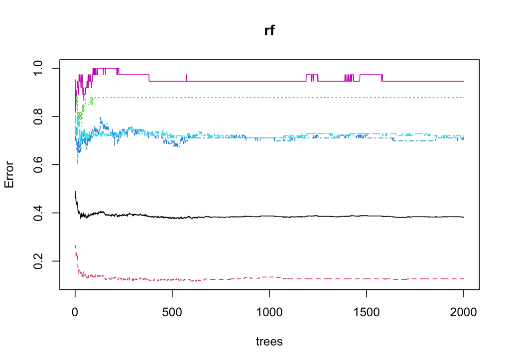

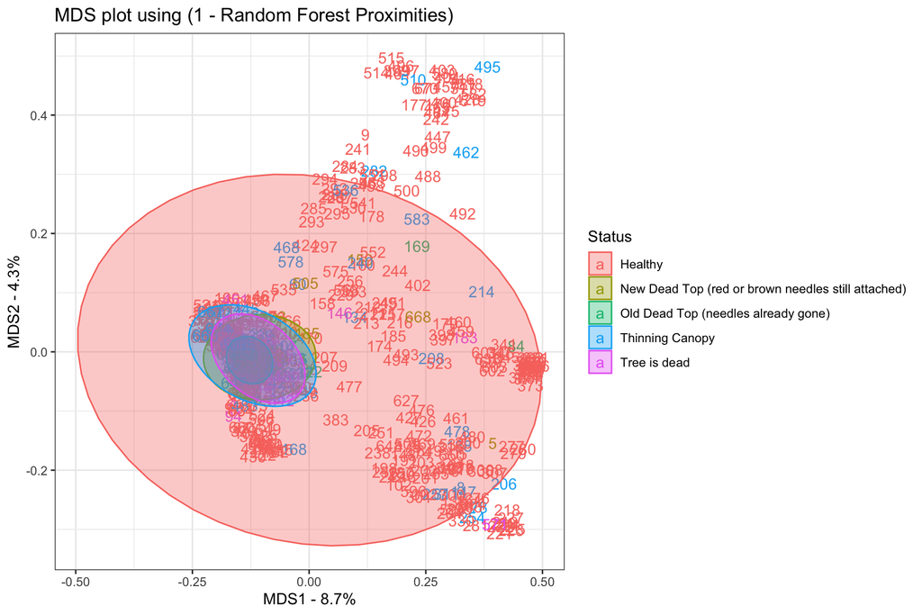

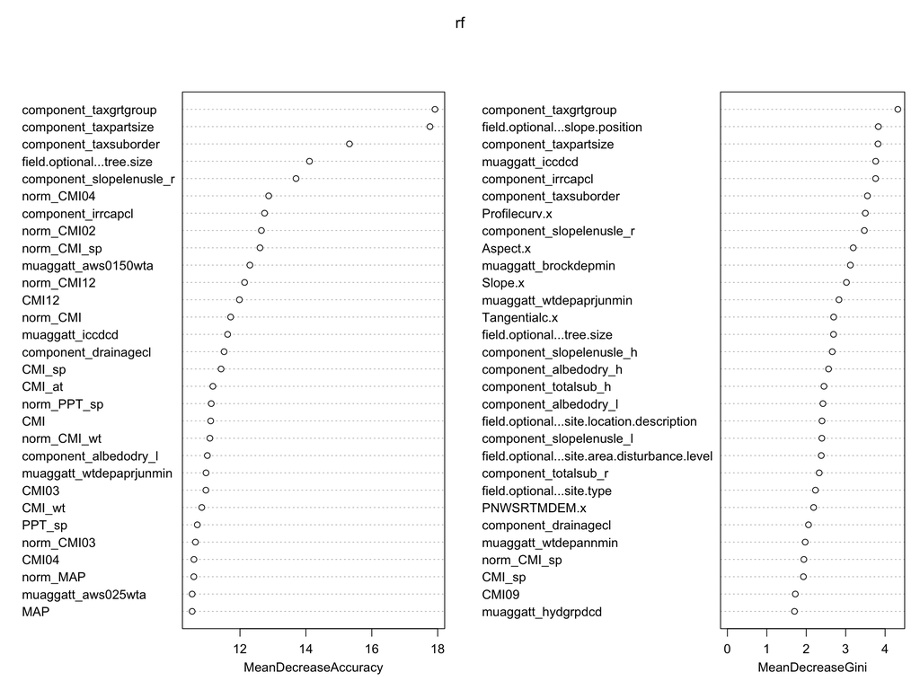

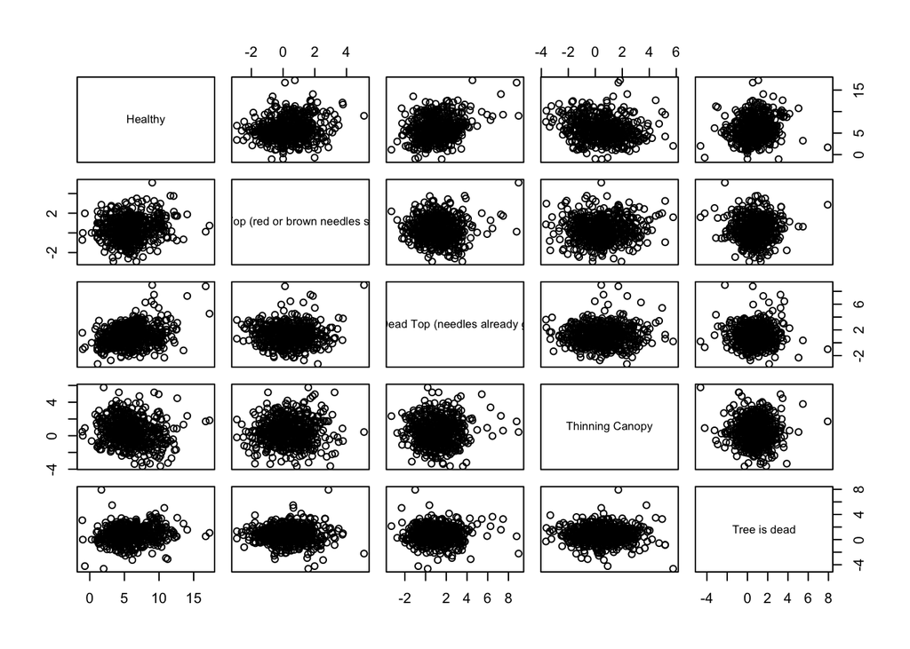

#### Monthless model

```
##
## Call:
##  randomForest(formula = field.tree.canopy.symptoms ~ ., data = data.imputed.monthless,      ntree = 2001, importance = TRUE, proximity = TRUE, na.action = na.omit)
##                Type of random forest: classification
##                      Number of trees: 2001
## No. of variables tried at each split: 15
##
##         OOB estimate of  error rate: 38.43%
## Confusion matrix:
##                                                    Healthy
## Healthy                                                357
## New Dead Top (red or brown needles still attached)      18
## Old Dead Top (needles already gone)                     35
## Thinning Canopy                                         58
## Tree is dead                                            20
##                                                    New Dead Top (red or brown needles still attached)
## Healthy                                                                                             5
## New Dead Top (red or brown needles still attached)                                                  4
## Old Dead Top (needles already gone)                                                                 2
## Thinning Canopy                                                                                     2
## Tree is dead                                                                                        2
##                                                    Old Dead Top (needles already gone)
## Healthy                                                                             17
## New Dead Top (red or brown needles still attached)                                   5
## Old Dead Top (needles already gone)                                                 20
## Thinning Canopy                                                                     24
## Tree is dead                                                                         5
##                                                    Thinning Canopy Tree is dead
## Healthy                                                         17            7
## New Dead Top (red or brown needles still attached)               4            2
## Old Dead Top (needles already gone)                             25            1
## Thinning Canopy                                                 31            3
## Tree is dead                                                     7            3
##                                                    class.error
## Healthy                                              0.1141439
## New Dead Top (red or brown needles still attached)   0.8787879
## Old Dead Top (needles already gone)                  0.7590361
## Thinning Canopy                                      0.7372881
## Tree is dead                                         0.9189189
```

> Note the ‘out of bag’ error rate of 38.5%

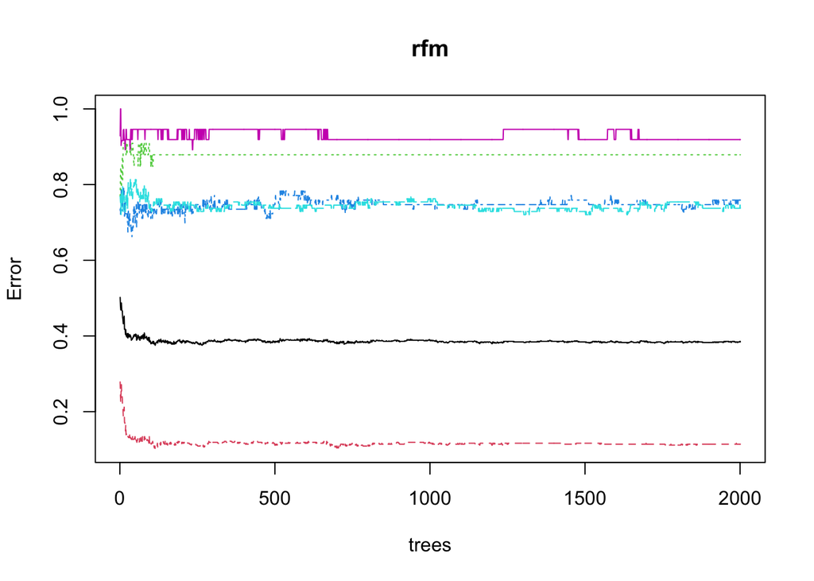

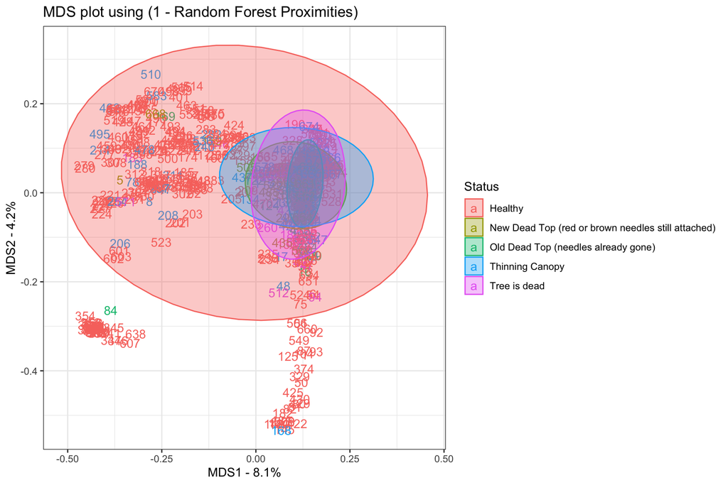

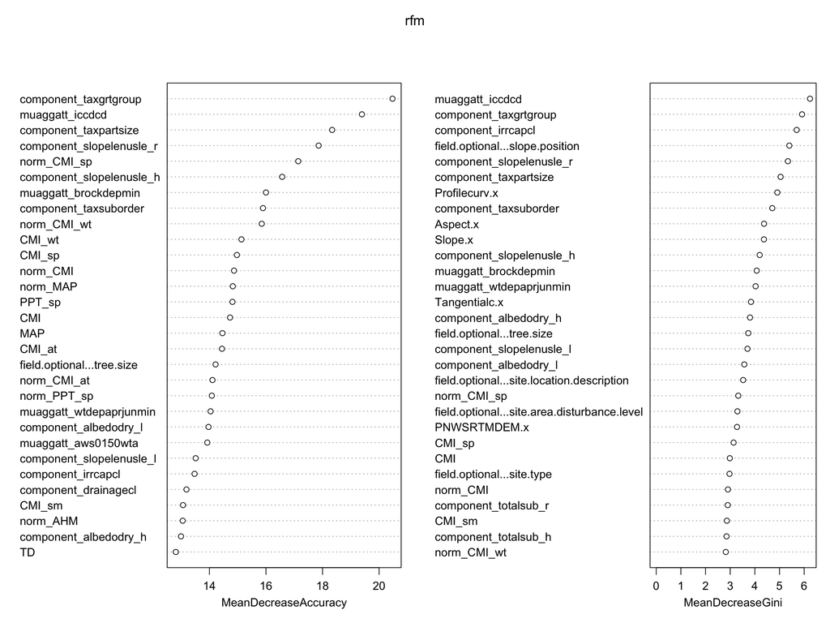

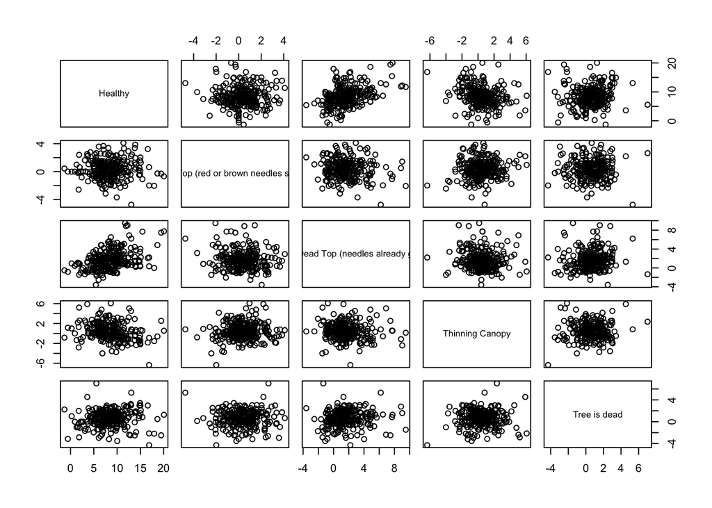

### Important Variables

#### Parameters evaluated in Case and Lawler 2017

CHILL FROST GDD0 GDD5 MAT MI_ANN MI_DECIDOUS MI_DJF MI_EVERGREEN MI_JJA MI_MAM MI_SON MTCO MTWA PET_ANN PET_DECIDOUS PET_DJF PET_EVERGREEN PET_JJA PET_MAM PET_SON PRANGE PREC_ANN PREC_ANN_MEA N PREC_DJF PREC_DRY PREC_JJA PREC_MAM PREC_MJJAS PREC_SON PREC_WET SWE_ANN TMP_DJF TMP_MAM TMP_SON TRANGE